# Chapter-9-ExerciseSolutions

2022-11-02

```r
head(ad)
```

```
##     GPA GMAT    De
## 1: 2.96  596 admit
## 2: 3.14  473 admit
## 3: 3.22  482 admit
## 4: 3.29  527 admit
## 5: 3.69  505 admit
## 6: 3.46  693 admit
```

1. Conduct a nonparametric test for the null hypothesis that the 75% percentile value of GMAT score is 600.

```r
#1. State the Null hypothesis : 75% percentile is 600,
#Step 2: Describe the data generation process and the population.
#Since the GMAT scores are numeric, we will assume they follow a normal distribution,
qnorm(0.75)
```

```
## [1] 0.6744898
```

```r
newm <- 600 - (qnorm(0.75) * sd(ad$GMAT))

newm
```

```
## [1] 545.014
```

```r
qnorm(0.75, mean = newm, sd = sd(ad$GMAT))
```

```
## [1] 600
```

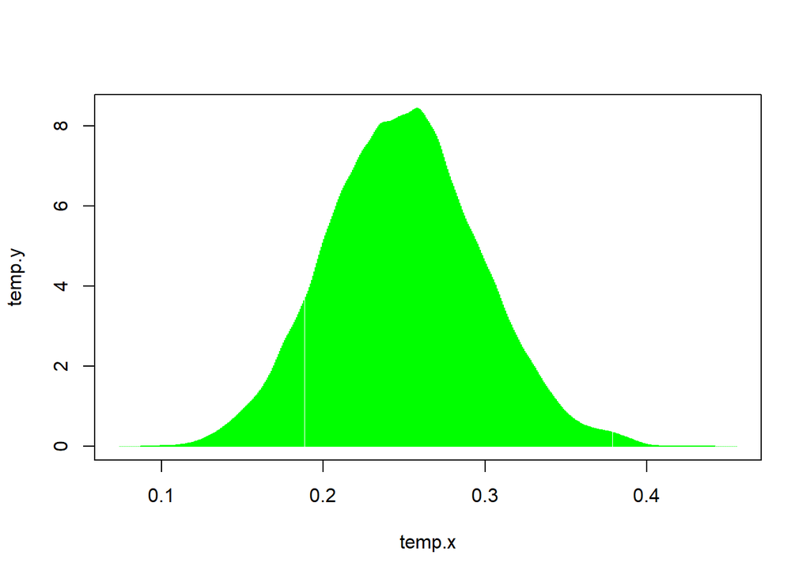

```
## [1] 0
```

```r
gmat_score <- 600

sampdist <- vector()

for (i in 1:10000) {

  s1 <- sample(c(0,1), size = nrow(ad), replace = T, prob = c(0.75, 0.25))
  sampdist <- append(sampdist, sum(s1) / nrow(ad))

}

df <-
  ad %>%
  copy() %>%
  .[, sign := ifelse(GMAT < gmat_score, 1, 0)] %>%
  .[, dev := GMAT - 600] %>%
  .[, .(sign, dev)] %>%
  .[order(dev)] %>%
  .[,rank := .I]

tstat <- sum(df[sign == 1, rank])

#P-value is zero and we reject the null hypothesis
p_2tail(sampdist, tstat)
```

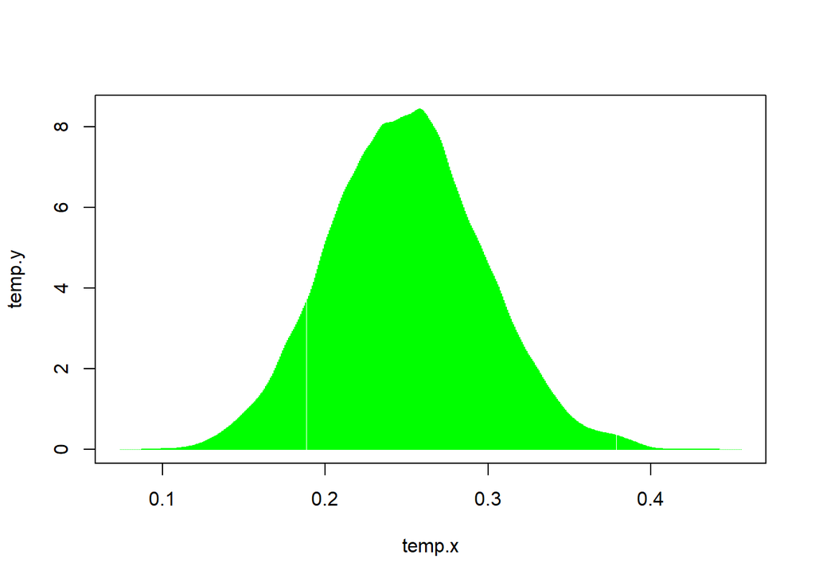

```
## [1] 0
```

```r
tstat <- quantile(ad$GMAT, 0.75)


p_2tail(sampdist, tstat)
```

2. A customer complains to the owner of an independent fast-food restaurant that the restaurant is discriminating against the elderly. The customer claims that people 60 years old and older are given fewer french fries than people under 60. The owner responds by gathering data, collected without the knowledge of the employees so as not to affect their behavior. Here are data on the weight of french fries (grams) for the two groups of customers:

Age less than 60: 75 77 80 69 73 76 78 74 75 81 75 80 79 80

Age greater than 60: 68 74 77 71 73 75 80 77 78 72 69 71 75 78

Conduct a nonparametric two-sample test to evaluate the complaint (i.e., whether the average weight is different in the two groups).

```r
age <- data.table(under60 = c(75,77,80,69,73,76,78,74,75,81,75,80,79,80),
                  over60 = c(68,74,77,71,73,75,80,77,78,72,69,71,75,78))
head(age)
```

```
##    under60 over60
## 1:      75     68
## 2:      77     74
## 3:      80     77
## 4:      69     71
## 5:      73     73
## 6:      76     75
```